# **Customer Churn Prediction System**

## **Project Objective**

Telecom companies lose money every time a customer leaves. The goal of this project is to build a machine learning model that can predict — before it happens — which customers are likely to leave (churn). Early prediction helps the business take action and retain high-risk customers.

## **Dataset**

A real-world telecom dataset containing information about:

- Customer usage behavior (calls, data, minutes)
- Revenue and billing details
- Service interaction (customer care, complaints)
- Device information
- Demographics
- Churn status (Yes / No) — our target

## **Target Variable**

`churn` → 1 = Customer Left, 0 = Customer Stayed

## **Project Workflow**

1. Import Libraries
2. Load Dataset
3. Data Understanding
4. Data Cleaning
5. Exploratory Data Analysis
6. Feature Engineering
7. Data Preprocessing
8. Model Building
9. Model Evaluation
10. Final Business Insights

# **Import Libraries**

```python
import pandas as pd
import numpy as np
import matplotlib.pyplot as plt
import seaborn as sns
from sklearn.model_selection import train_test_split
from sklearn.preprocessing import LabelEncoder, StandardScaler
from sklearn.linear_model import LogisticRegression
from sklearn.metrics import accuracy_score, precision_score, recall_score, f1_score
from sklearn.metrics import confusion_matrix, classification_report
from sklearn.metrics import roc_curve, roc_auc_score
import warnings
warnings.filterwarnings("ignore")
```

# **Load Dataset**

```python
df = pd.read_csv("Telecom_customer_churn.csv")
```

```python
df.head()
```

|  | rev_Mean | mou_Mean | ovrmou_Mean | ovrrev_Mean | change_mou | change_rev | drop_vce_Mean | blck_vce_Mean | plcd_vce_Mean | recv_vce_Mean | ... | numbcars | dwllsize | kid0_2 | kid3_5 | kid6_10 | kid11_15 | kid16_17 | creditcd | eqpdays | Customer_ID |
| --- | --- | --- | --- | --- | --- | --- | --- | --- | --- | --- | --- | --- | --- | --- | --- | --- | --- | --- | --- | --- | --- |
| 0 | 23.9975 | 219.25 | 0.00 | 0.0 | -157.25 | -18.9975 | 0.666667 | 0.666667 | 52.333333 | 42.333333 | ... | 3.0 | A | U | U | U | U | U | Y | 361.0 | 1000001 |
| 1 | 57.4925 | 482.75 | 22.75 | 9.1 | 532.25 | 50.9875 | 8.333333 | 1.000000 | 263.333333 | 69.000000 | ... | 1.0 | A | U | U | U | U | U | Y | 240.0 | 1000002 |
| 2 | 16.9900 | 10.25 | 0.00 | 0.0 | -4.25 | 0.0000 | 0.333333 | 0.000000 | 9.000000 | 0.333333 | ... | 2.0 | A | U | Y | U | U | U | Y | 1504.0 | 1000003 |
| 3 | 38.0000 | 7.50 | 0.00 | 0.0 | -1.50 | 0.0000 | 0.000000 | 0.000000 | 3.666667 | 1.333333 | ... | 1.0 | D | Y | U | U | U | U | Y | 1812.0 | 1000004 |
| 4 | 55.2300 | 570.50 | 0.00 | 0.0 | 38.50 | 0.0000 | 9.666667 | 0.666667 | 222.333333 | 94.666667 | ... | 1.0 | O | U | U | U | U | U | Y | 434.0 | 1000005 |

5 rows × 67 columns

```python
df.tail()
```

|  | rev_Mean | mou_Mean | ovrmou_Mean | ovrrev_Mean | change_mou | change_rev | drop_vce_Mean | blck_vce_Mean | plcd_vce_Mean | recv_vce_Mean | ... | numbcars | dwllsize | kid0_2 | kid3_5 | kid6_10 | kid11_15 | kid16_17 | creditcd | eqpdays | Customer_ID |
| --- | --- | --- | --- | --- | --- | --- | --- | --- | --- | --- | --- | --- | --- | --- | --- | --- | --- | --- | --- | --- | --- |
| 99995 | NaN | NaN | NaN | NaN | NaN | NaN | 2.000000 | 0.000000 | 54.666667 | 3.000000 | ... | 2.0 | A | U | U | U | Y | U | Y | 773.0 | 1099996 |
| 99996 | NaN | NaN | NaN | NaN | NaN | NaN | 3.000000 | 1.000000 | 69.333333 | 15.333333 | ... | 2.0 | A | U | U | Y | Y | Y | Y | 835.0 | 1099997 |
| 99997 | NaN | NaN | NaN | NaN | NaN | NaN | 0.000000 | 0.000000 | 0.000000 | 0.000000 | ... | NaN | NaN | Y | Y | U | U | U | N | 433.0 | 1099998 |
| 99998 | NaN | NaN | NaN | NaN | NaN | NaN | 18.666667 | 0.666667 | 550.666667 | 327.000000 | ... | NaN | NaN | U | U | U | U | U | N | 75.0 | 1099999 |
| 99999 | NaN | NaN | NaN | NaN | NaN | NaN | 5.666667 | 0.666667 | 155.666667 | 1.333333 | ... | NaN | A | U | U | U | U | U | N | 5.0 | 1100000 |

5 rows × 67 columns

```python
df.shape
```

```
(100000, 67)
```

```python
df.columns
```

```
Index(['rev_Mean', 'mou_Mean', 'ovrmou_Mean', 'ovrrev_Mean', 'change_mou',
       'change_rev', 'drop_vce_Mean', 'blck_vce_Mean', 'plcd_vce_Mean',
       'recv_vce_Mean', 'recv_sms_Mean', 'comp_vce_Mean', 'custcare_Mean',
       'ccrndmou_Mean', 'cc_mou_Mean', 'threeway_Mean', 'mou_cvce_Mean',
       'mou_rvce_Mean', 'peak_vce_Mean', 'mou_peav_Mean', 'opk_vce_Mean',
       'mou_opkv_Mean', 'drop_blk_Mean', 'attempt_Mean', 'complete_Mean',
       'callwait_Mean', 'churn', 'months', 'uniqsubs', 'actvsubs', 'new_cell',
       'asl_flag', 'totcalls', 'totmou', 'totrev', 'adjrev', 'adjmou',
       'avgrev', 'avgmou', 'avg3mou', 'avg3qty', 'avg3rev', 'avg6mou',
       'avg6rev', 'dualband', 'refurb_new', 'hnd_price', 'phones', 'models',
       'hnd_webcap', 'truck', 'rv', 'ownrent', 'dwlltype', 'marital', 'adults',
       'income', 'numbcars', 'dwllsize', 'kid0_2', 'kid3_5', 'kid6_10',
       'kid11_15', 'kid16_17', 'creditcd', 'eqpdays', 'Customer_ID'],
      dtype='str')
```

```python
df.info()
```

```
<class 'pandas.DataFrame'>
RangeIndex: 100000 entries, 0 to 99999
Data columns (total 67 columns):
 #   Column         Non-Null Count   Dtype
---  ------         --------------   -----
 0   rev_Mean       99643 non-null   float64
 1   mou_Mean       99643 non-null   float64
 2   ovrmou_Mean    99643 non-null   float64
 3   ovrrev_Mean    99643 non-null   float64
 4   change_mou     99109 non-null   float64
 5   change_rev     99109 non-null   float64
 6   drop_vce_Mean  100000 non-null  float64
 7   blck_vce_Mean  100000 non-null  float64
 8   plcd_vce_Mean  100000 non-null  float64
 9   recv_vce_Mean  100000 non-null  float64
```

[output cut: 59 more lines]

```python
df.describe()
```

|  | rev_Mean | mou_Mean | ovrmou_Mean | ovrrev_Mean | change_mou | change_rev | drop_vce_Mean | blck_vce_Mean | plcd_vce_Mean | recv_vce_Mean | ... | hnd_price | phones | models | truck | rv | adults | income | numbcars | eqpdays | Customer_ID |
| --- | --- | --- | --- | --- | --- | --- | --- | --- | --- | --- | --- | --- | --- | --- | --- | --- | --- | --- | --- | --- | --- |
| count | 99643.000000 | 99643.000000 | 99643.000000 | 99643.000000 | 99109.000000 | 99109.000000 | 100000.000000 | 100000.000000 | 100000.000000 | 100000.000000 | ... | 99153.000000 | 99999.000000 | 99999.000000 | 98268.000000 | 98268.000000 | 76981.000000 | 74564.000000 | 50634.000000 | 99999.000000 | 1.000000e+05 |
| mean | 58.719985 | 513.559937 | 41.072247 | 13.559560 | -13.933818 | -1.021067 | 5.955085 | 4.022917 | 144.881677 | 55.085152 | ... | 101.875763 | 1.787118 | 1.545825 | 0.188820 | 0.082580 | 2.530326 | 5.783112 | 1.567563 | 391.932309 | 1.050000e+06 |
| std | 46.291677 | 525.168140 | 97.296150 | 30.500885 | 276.087509 | 50.363209 | 8.954715 | 10.672202 | 158.267711 | 86.841198 | ... | 61.005671 | 1.313977 | 0.898395 | 0.391368 | 0.275248 | 1.452819 | 2.182132 | 0.625456 | 256.482193 | 2.886766e+04 |
| min | -6.167500 | 0.000000 | 0.000000 | 0.000000 | -3875.000000 | -1107.740000 | 0.000000 | 0.000000 | 0.000000 | 0.000000 | ... | 9.989998 | 1.000000 | 1.000000 | 0.000000 | 0.000000 | 1.000000 | 1.000000 | 1.000000 | -5.000000 | 1.000001e+06 |
| 25% | 33.260000 | 150.750000 | 0.000000 | 0.000000 | -87.000000 | -7.365000 | 0.666667 | 0.000000 | 38.333333 | 5.333333 | ... | 29.989990 | 1.000000 | 1.000000 | 0.000000 | 0.000000 | 1.000000 | 4.000000 | 1.000000 | 212.000000 | 1.025001e+06 |
| 50% | 48.195000 | 355.500000 | 2.750000 | 1.000000 | -6.250000 | -0.315000 | 3.000000 | 1.000000 | 100.333333 | 26.666667 | ... | 99.989990 | 1.000000 | 1.000000 | 0.000000 | 0.000000 | 2.000000 | 6.000000 | 1.000000 | 342.000000 | 1.050000e+06 |
| 75% | 70.750000 | 703.000000 | 42.000000 | 14.437500 | 63.000000 | 1.642500 | 7.666667 | 3.666667 | 198.666667 | 71.333333 | ... | 149.989990 | 2.000000 | 2.000000 | 0.000000 | 0.000000 | 3.000000 | 7.000000 | 2.000000 | 530.000000 | 1.075000e+06 |
| max | 3843.262500 | 12206.750000 | 4320.750000 | 1102.400000 | 31219.250000 | 9963.657500 | 232.666667 | 385.333333 | 2289.000000 | 3369.333333 | ... | 499.989990 | 28.000000 | 16.000000 | 1.000000 | 1.000000 | 6.000000 | 9.000000 | 3.000000 | 1823.000000 | 1.100000e+06 |

8 rows × 52 columns

*This step helps us understand the dataset structure, number of rows and columns, data types, numerical distribution, and target column.*

# **Data Understanding**

```python
df["churn"].value_counts()   ###  1 means Customer Left, 0 means Customer Stayed
```

```
churn
0    50438
1    49562
Name: count, dtype: int64
```

```python
df["churn"].value_counts(normalize=True) * 100
```

```
churn
0    50.438
1    49.562
Name: proportion, dtype: float64
```

```python
num_cols = df.select_dtypes(include=["int64", "float64"]).columns
cat_cols = df.select_dtypes(include=["object", "string"]).columns

print("Numerical Columns:", len(num_cols))
print(num_cols)

print("Categorical Columns:", len(cat_cols))
print(cat_cols)
```

```
Numerical Columns: 52
Index(['rev_Mean', 'mou_Mean', 'ovrmou_Mean', 'ovrrev_Mean', 'change_mou',
       'change_rev', 'drop_vce_Mean', 'blck_vce_Mean', 'plcd_vce_Mean',
       'recv_vce_Mean', 'recv_sms_Mean', 'comp_vce_Mean', 'custcare_Mean',
       'ccrndmou_Mean', 'cc_mou_Mean', 'threeway_Mean', 'mou_cvce_Mean',
       'mou_rvce_Mean', 'peak_vce_Mean', 'mou_peav_Mean', 'opk_vce_Mean',
       'mou_opkv_Mean', 'drop_blk_Mean', 'attempt_Mean', 'complete_Mean',
       'callwait_Mean', 'churn', 'months', 'uniqsubs', 'actvsubs', 'totcalls',
       'totmou', 'totrev', 'adjrev', 'adjmou', 'avgrev', 'avgmou', 'avg3mou',
       'avg3qty', 'avg3rev', 'avg6mou', 'avg6rev', 'hnd_price', 'phones',
       'models', 'truck', 'rv', 'adults', 'income', 'numbcars', 'eqpdays',
       'Customer_ID'],
      dtype='str')
Categorical Columns: 15
Index(['new_cell', 'asl_flag', 'dualband', 'refurb_new', 'hnd_webcap',
       'ownrent', 'dwlltype', 'marital', 'dwllsize', 'kid0_2', 'kid3_5',
       'kid6_10', 'kid11_15', 'kid16_17', 'creditcd'],
      dtype='str')
```

```python
for col in cat_cols:
    print(col)
    print(df[col].value_counts())
    print("-" * 50)
```

```
new_cell
new_cell
U    66914
Y    19301
N    13785
Name: count, dtype: int64
--------------------------------------------------
asl_flag
asl_flag
N    86064
Y    13936
Name: count, dtype: int64
--------------------------------------------------
dualband
dualband
Y    72265
N    23196
T     4316
U      222
Name: count, dtype: int64
--------------------------------------------------
refurb_new
refurb_new
N    85593
R    14406
Name: count, dtype: int64
--------------------------------------------------
hnd_webcap
hnd_webcap
WCMB    75733
WC      13843
UNKW      235
Name: count, dtype: int64
--------------------------------------------------
ownrent
ownrent
O    64284
R     2010
Name: count, dtype: int64
--------------------------------------------------
```

[output cut: 55 more lines]

```
Y     8814
Name: count, dtype: int64
--------------------------------------------------
kid16_17
kid16_17
U    88304
Y     9964
Name: count, dtype: int64
--------------------------------------------------
creditcd
creditcd
Y    67234
N    31034
Name: count, dtype: int64
--------------------------------------------------
```

# **Data Cleaning**

```python
# Missing Values

missing_values = df.isnull().sum()
missing_percent = (df.isnull().sum() / len(df)) * 100

missing_df = pd.DataFrame({
    "Missing Values": missing_values,
    "Missing Percentage": missing_percent
})

missing_df[missing_df["Missing Values"] > 0].sort_values(by="Missing Percentage", ascending=False)
```

|  | Missing Values | Missing Percentage |
| --- | --- | --- |
| numbcars | 49366 | 49.366 |
| dwllsize | 38308 | 38.308 |
| ownrent | 33706 | 33.706 |
| dwlltype | 31909 | 31.909 |
| income | 25436 | 25.436 |
| adults | 23019 | 23.019 |
| hnd_webcap | 10189 | 10.189 |
| avg6mou | 2839 | 2.839 |
| avg6rev | 2839 | 2.839 |
| truck | 1732 | 1.732 |
| rv | 1732 | 1.732 |
| kid3_5 | 1732 | 1.732 |
| kid0_2 | 1732 | 1.732 |
| marital | 1732 | 1.732 |
| kid11_15 | 1732 | 1.732 |
| kid16_17 | 1732 | 1.732 |
| creditcd | 1732 | 1.732 |
| kid6_10 | 1732 | 1.732 |
| change_mou | 891 | 0.891 |
| change_rev | 891 | 0.891 |
| hnd_price | 847 | 0.847 |
| ovrmou_Mean | 357 | 0.357 |
| mou_Mean | 357 | 0.357 |
| rev_Mean | 357 | 0.357 |
| ovrrev_Mean | 357 | 0.357 |
| refurb_new | 1 | 0.001 |
| models | 1 | 0.001 |
| phones | 1 | 0.001 |
| dualband | 1 | 0.001 |
| eqpdays | 1 | 0.001 |

```python
# Duplicate Check

duplicate_count = df.duplicated().sum()

print("Duplicate Rows:", duplicate_count)
```

```
Duplicate Rows: 0
```

```python
# Customer_ID Duplicate Check

duplicate_customerid = df["Customer_ID"].duplicated().sum()
print("Duplicate Customer ID:", duplicate_customerid)
```

```
Duplicate Customer ID: 0
```

```python
# Missing Value Handling
## Numerical columns

num_cols = df.select_dtypes(include=["int64", "float64"]).columns

for col in num_cols:
    df[col] = df[col].fillna(df[col].median())
```

```python
df.isnull().sum().sum()
```

```
np.int64(126238)
```

```python
df.isnull().sum()
```

```
rev_Mean          0
mou_Mean          0
ovrmou_Mean       0
ovrrev_Mean       0
change_mou        0
               ...
kid11_15       1732
kid16_17       1732
creditcd       1732
eqpdays           0
Customer_ID       0
Length: 67, dtype: int64
```

```python
## Categorical columns

cat_cols = df.select_dtypes(include=["object", "string"]).columns

for col in cat_cols:
    df[col] = df[col].fillna(df[col].mode()[0])
```

```python
df.isnull().sum().sum()
```

```
np.int64(0)
```

```python
df.isnull().sum()
```

```
rev_Mean       0
mou_Mean       0
ovrmou_Mean    0
ovrrev_Mean    0
change_mou     0
              ..
kid11_15       0
kid16_17       0
creditcd       0
eqpdays        0
Customer_ID    0
Length: 67, dtype: int64
```

```python
# Category Cleaning
for col in cat_cols:
    df[col] = df[col].astype(str).str.strip().str.upper()
```

```python
# Final Clean Check
df.isnull().sum()
```

```
rev_Mean       0
mou_Mean       0
ovrmou_Mean    0
ovrrev_Mean    0
change_mou     0
              ..
kid11_15       0
kid16_17       0
creditcd       0
eqpdays        0
Customer_ID    0
Length: 67, dtype: int64
```

```python
df.shape
```

```
(100000, 67)
```

*After cleaning, The dataset is now clean and ready for analysis.*

All missing values have been filled — numbers were replaced with the median value, and text/category columns were filled with the most common value (mode).

No duplicate rows remain in the dataset.

# **Exploratory Data Analysis (EDA)**

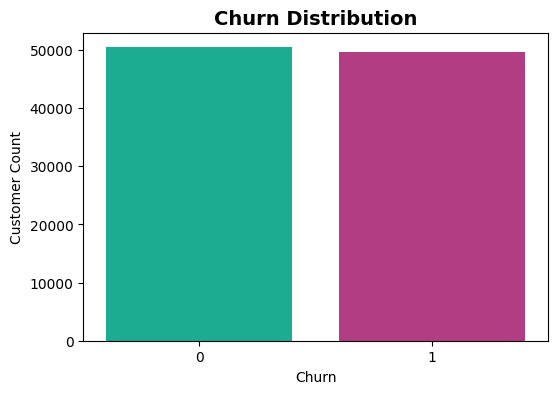

```python
# Churn Distribution
plt.figure(figsize=(6,4))
sns.countplot(data=df, x="churn",palette=["#03C4A1", "#C52A87"],legend=False)
plt.title("Churn Distribution", fontsize=14, fontweight="bold")
plt.xlabel("Churn")
plt.ylabel("Customer Count")
plt.show()
```

```python
df["churn"].value_counts(normalize=True) * 100
```

```
churn
0    50.438
1    49.562
Name: proportion, dtype: float64
```

*This chart shows the proportion of customers who stay and did not stay. It helps identify whether the dataset is balanced or imbalanced.*

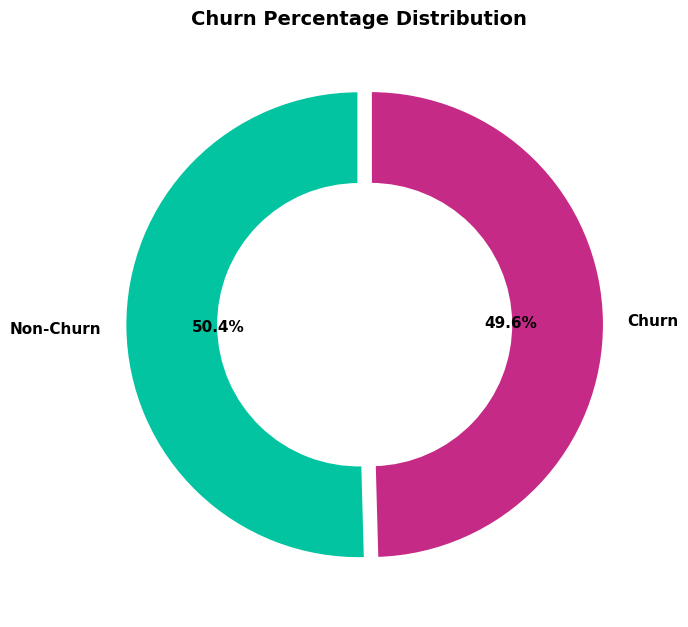

```python
# Churn %

churn_counts = df["churn"].value_counts()
plt.figure(figsize=(7,7))
colors = ["#03C4A1", "#C52A87"]

plt.pie(churn_counts,labels=["Non-Churn", "Churn"],autopct="%1.1f%%",
    startangle=90,colors=colors,explode=(0, 0.05),
    wedgeprops={"width": 0.4,"edgecolor": "white","linewidth": 2},
    textprops={"fontsize": 11,"fontweight": "bold"}
)

plt.title("Churn Percentage Distribution",fontsize=14,fontweight="bold")
plt.tight_layout()
plt.show()
```

*Dataset is balanced.*

Churn: 49.6% Non-Churn: 50.4%

Almost equal split — no imbalance problem. Model will train fairly on both groups.

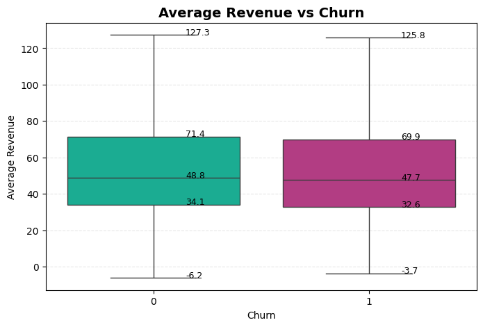

```python
# Revenue vs Churn

plt.figure(figsize=(8,5))
ax = sns.boxplot(data=df,x="churn",y="rev_Mean",hue="churn",
    palette=["#03C4A1", "#C52A87"],legend=False,showfliers=False)
plt.title("Average Revenue vs Churn", fontsize=14, fontweight="bold")
plt.xlabel("Churn")
plt.ylabel("Average Revenue")
plt.grid(axis="y", linestyle="--", alpha=0.3)

# Add boxplot values
for i, category in enumerate(sorted(df["churn"].unique())):
    values = df[df["churn"] == category]["rev_Mean"]
    q1 = values.quantile(0.25)
    median = values.median()
    q3 = values.quantile(0.75)
    iqr = q3 - q1
    lower_whisker = values[values >= q1 - 1.5 * iqr].min()
    upper_whisker = values[values <= q3 + 1.5 * iqr].max()
    stats = [lower_whisker, q1, median, q3, upper_whisker]
    for stat in stats:
        ax.text(
            i + 0.15,
            stat,
            f"{stat:.1f}",
            fontsize=9,
            color="black"
        )
plt.show()
```

*From this chart, I can see that churned customers (1) and non-churned customers (0) have very similar revenue patterns.*

Non-churned customers:

- Median revenue: 48.8
- Range: -6.2 to 127.3

Churned customers:

- Median revenue: 47.7
- Range: -3.7 to 125.8

Key finding: Revenue alone cannot predict churn.A customer paying high amount can still leave — which means price is not the main reason people churn. This tells us we need to look at other factors like service quality, dropped calls, and customer care interactions to understand why customers are leaving.

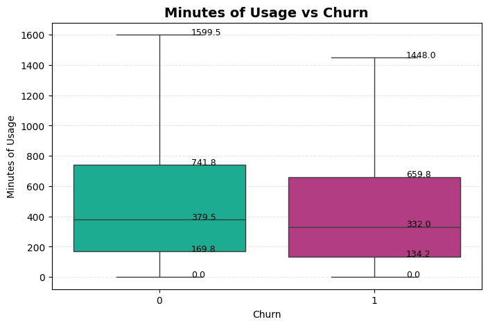

```python
# Usage vs Churn
plt.figure(figsize=(8,5))
ax = sns.boxplot(data=df,x="churn",y="mou_Mean",hue="churn",palette=["#03C4A1", "#C52A87"],
    legend=False,showfliers=False)
plt.title("Minutes of Usage vs Churn", fontsize=14, fontweight="bold")
plt.xlabel("Churn")
plt.ylabel("Minutes of Usage")
plt.grid(axis="y", linestyle="--", alpha=0.3)

# Add boxplot values
for i, category in enumerate(sorted(df["churn"].unique())):
    values = df[df["churn"] == category]["mou_Mean"]
    q1 = values.quantile(0.25)
    median = values.median()
    q3 = values.quantile(0.75)
    iqr = q3 - q1
    lower_whisker = values[values >= q1 - 1.5 * iqr].min()
    upper_whisker = values[values <= q3 + 1.5 * iqr].max()
    stats = [lower_whisker, q1, median, q3, upper_whisker]
    for stat in stats:
        ax.text(
            i + 0.15,
            stat,
            f"{stat:.1f}",
            fontsize=9,
            color="black"
        )
plt.show()
```

*From this chart, I can see a clear difference in usage between churned and non-churned customers.*

Non-churned customers (0):

- Median usage: 379.5 minutes
- Range: 0 to 1599.5 minutes

Churned customers (1):

- Median usage: 332.0 minutes
- Range: 0 to 1448.0 minutes

Key finding: Customers who churned used the service LESS than customers who stayed.

Median difference: 379.5 - 332.0 = 47.5 minutes This is more meaningful than revenue. Low usage = low engagement = higher churn risk.

A customer who rarely uses the service is already mentally disconnecting before they officially leave.

This makes "usage" a potentially important feature for our model.

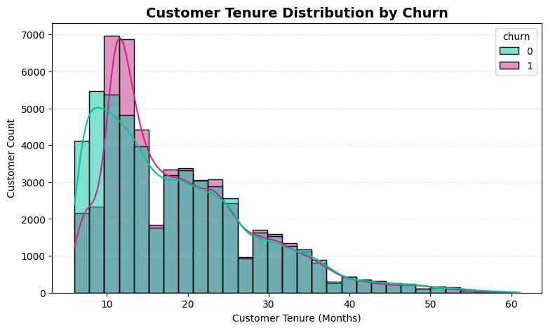

```python
# Tenure vs Churn

plt.figure(figsize=(9,5))

sns.histplot(data=df,x="months",hue="churn",bins=30,kde=True,
    palette=["#03C4A1", "#C52A87"],alpha=0.5)

plt.title("Customer Tenure Distribution by Churn",fontsize=14,fontweight="bold")

plt.xlabel("Customer Tenure (Months)")
plt.ylabel("Customer Count")

plt.grid(axis="y", linestyle="--", alpha=0.3)

plt.show()
```

*This chart shows that new customers leave more, old customers stay.*

Churned customers mostly left within the first 8 to 15 months.

So the company should give extra attention to new customers in the first year.

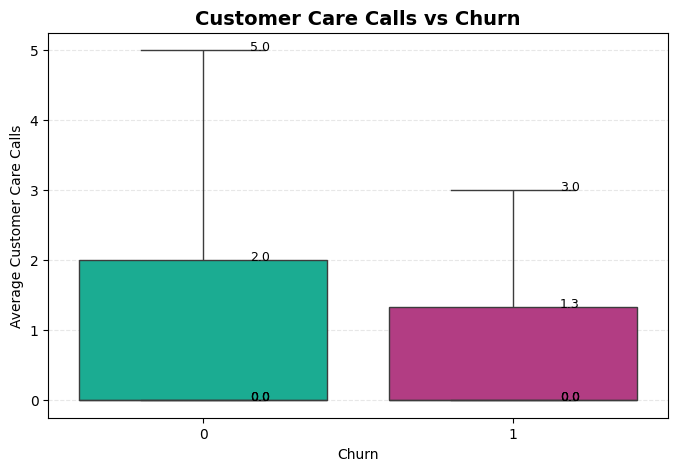

```python
# Customer Care Calls vs Churn

plt.figure(figsize=(8,5))
ax = sns.boxplot(data=df,x="churn",y="custcare_Mean",hue="churn",
    palette=["#03C4A1", "#C52A87"],legend=False,showfliers=False)

plt.title("Customer Care Calls vs Churn",fontsize=14,fontweight="bold")

plt.xlabel("Churn")
plt.ylabel("Average Customer Care Calls")

plt.grid(axis="y", linestyle="--", alpha=0.3)

for i, category in enumerate(sorted(df["churn"].unique())):
    values = df[df["churn"] == category]["custcare_Mean"]
    q1 = values.quantile(0.25)
    median = values.median()
    q3 = values.quantile(0.75)
    iqr = q3 - q1
    lower_whisker = values[values >= q1 - 1.5 * iqr].min()
    upper_whisker = values[values <= q3 + 1.5 * iqr].max()
    stats = [lower_whisker, q1, median, q3, upper_whisker]
    for stat in stats:
        ax.text(
            i + 0.15,
            stat,
            f"{stat:.1f}",
            fontsize=9,
            color="black"
        )
plt.show()
```

Customers who complain are still trying.They want the problem fixed.

Customers who left (1) stopped calling — they already gave up and quietly left.

Simple rule: Less customer care calls = already given up = higher churn risk.

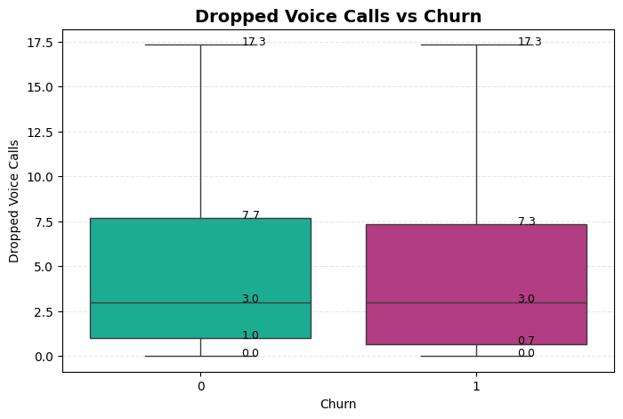

```python
# Dropped Calls vs Churn

plt.figure(figsize=(8,5))

ax = sns.boxplot(data=df,x="churn",y="drop_vce_Mean",hue="churn",
    palette=["#03C4A1", "#C52A87"],legend=False,showfliers=False
)

plt.title("Dropped Voice Calls vs Churn",fontsize=14,fontweight="bold")
plt.xlabel("Churn")
plt.ylabel("Dropped Voice Calls")
plt.grid(axis="y", linestyle="--", alpha=0.3)

for i, category in enumerate(sorted(df["churn"].unique())):
    values = df[df["churn"] == category]["drop_vce_Mean"]
    q1 = values.quantile(0.25)
    median = values.median()
    q3 = values.quantile(0.75)
    iqr = q3 - q1
    lower_whisker = values[values >= q1 - 1.5 * iqr].min()
    upper_whisker = values[values <= q3 + 1.5 * iqr].max()
    stats = [lower_whisker, q1, median, q3, upper_whisker]
    for stat in stats:
        ax.text(
            i + 0.15,
            stat,
            f"{stat:.1f}",
            fontsize=9,
            color="black"
        )

plt.show()
```

*Both churned (1) and non-churned (0) customers have almost identical dropped call patterns.*

Non-churned (0): median 3.0, max 17.3 Churned (1): median 3.0, max 17.3

Difference: almost zero.

This means dropped calls alone do not cause churn directly.

A customer tolerates dropped calls — but when dropped calls combine with poor service and low usage,that is when they finally leave.

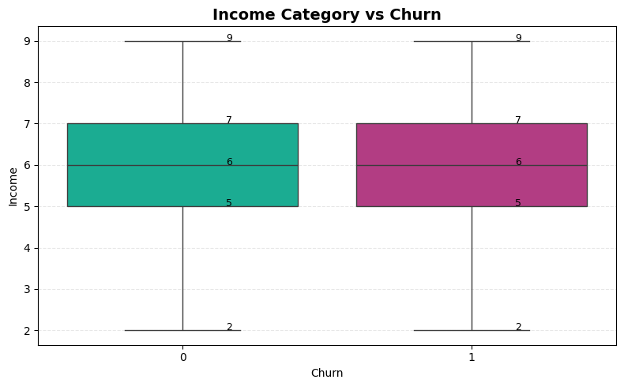

```python
# Income vs Churn

plt.figure(figsize=(8,5))

ax = sns.boxplot(data=df,x="churn",y="income",hue="churn",palette=["#03C4A1", "#C52A87"],legend=False,showfliers=False)

plt.title("Income Category vs Churn",fontsize=14,fontweight="bold")

plt.xlabel("Churn")
plt.ylabel("Income")

plt.grid(axis="y", linestyle="--", alpha=0.3)

for i, category in enumerate(sorted(df["churn"].unique())):
    values = df[df["churn"] == category]["income"]
    q1 = values.quantile(0.25)
    median = values.median()
    q3 = values.quantile(0.75)
    iqr = q3 - q1
    lower_whisker = values[values >= q1 - 1.5 * iqr].min()
    upper_whisker = values[values <= q3 + 1.5 * iqr].max()
    stats = [lower_whisker, q1, median, q3, upper_whisker]

    for stat in stats:
        ax.text(
            i + 0.15,
            stat,
            f"{stat:,.0f}",
            fontsize=9,
            color="black"
        )

plt.tight_layout()

plt.show()
```

*Both churned and non-churned customers have identical income distribution.*

Non-churned (0): median 6, range 2 to 9

Churned (1): median 6, range 2 to 9

Difference: zero.

Income does not affect churn at all. Rich or poor — both groups leave equally.

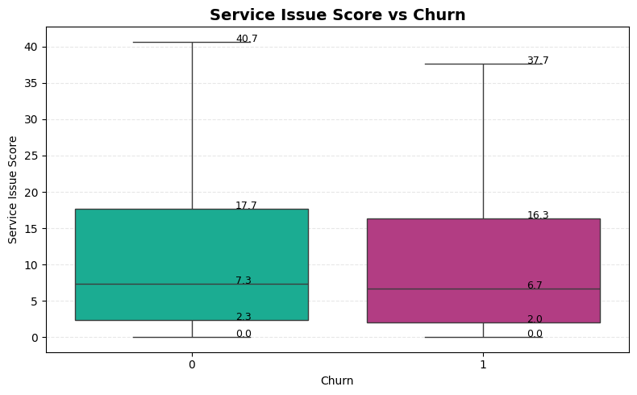

```python
# Service Issue Score Analysis

## Create Service Issue Score
df["service_issue_score"] = (
    df["drop_vce_Mean"] +
    df["blck_vce_Mean"] +
    df["custcare_Mean"] +
    df["callwait_Mean"]
)

plt.figure(figsize=(8,5))

ax = sns.boxplot(data=df,x="churn",y="service_issue_score",hue="churn",
    palette=["#03C4A1", "#C52A87"],legend=False,showfliers=False)

plt.title("Service Issue Score vs Churn",fontsize=14,fontweight="bold")

plt.xlabel("Churn")
plt.ylabel("Service Issue Score")

plt.grid(axis="y", linestyle="--", alpha=0.3)

for i, category in enumerate(sorted(df["churn"].unique())):
    values = df[df["churn"] == category]["service_issue_score"]
    q1 = values.quantile(0.25)
    median = values.median()
    q3 = values.quantile(0.75)
    iqr = q3 - q1
    lower_whisker = values[values >= q1 - 1.5 * iqr].min()
    upper_whisker = values[values <= q3 + 1.5 * iqr].max()
    stats = [lower_whisker, q1, median, q3, upper_whisker]

    for stat in stats:
        ax.text(
            i + 0.15,
            stat,
            f"{stat:.1f}",
            fontsize=9,
            color="black"
        )

plt.tight_layout()

plt.show()
```

*Service Issue Score = dropped calls + blocked calls + customer care + call waiting.*

Non-churned (0): median 7.3

Churned (1): median 6.7

Difference is very small.

Surprisingly, churned customers had slightly LESS service issues.

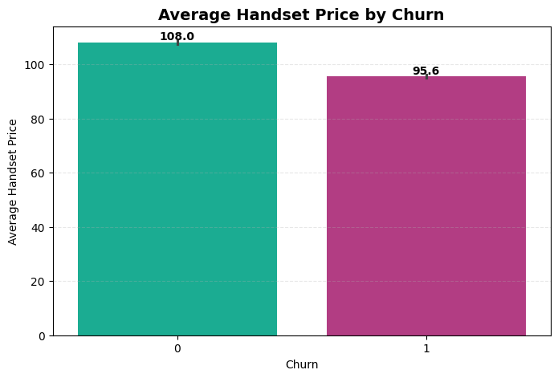

```python
# Device Price vs Churn

plt.figure(figsize=(8,5))

ax = sns.barplot(data=df,x="churn",y="hnd_price",hue="churn",
    palette=["#03C4A1", "#C52A87"],legend=False,estimator="mean")

plt.title("Average Handset Price by Churn",fontsize=14,fontweight="bold")
plt.xlabel("Churn")
plt.ylabel("Average Handset Price")
plt.grid(axis="y", linestyle="--", alpha=0.3)

for p in ax.patches:
    ax.annotate(
        f"{p.get_height():.1f}",
        (p.get_x() + p.get_width()/2, p.get_height()),
        ha='center',
        va='bottom',
        fontsize=10,
        fontweight='bold'
    )

plt.show()
```

*Customers who stayed (0) had higher average handset price — 108.0*

Customers who left (1) had lower average handset price — 95.6

Difference: 12.4

Customers with expensive devices are more invested in the service.They have more to lose by switching.

Customers with cheaper devices switch more easily — less commitment, less switching cost.

So handset price is a moderate signal for churn. Not the strongest, but still useful for the model.

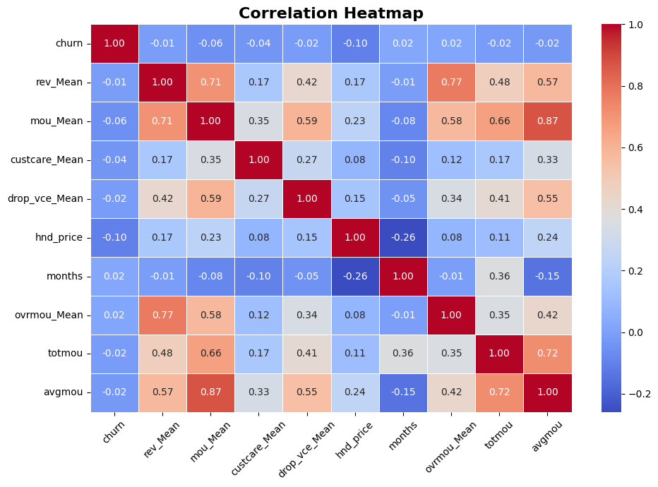

```python
# Correlation Heatmap

important_cols = [
    "churn",
    "rev_Mean",
    "mou_Mean",
    "custcare_Mean",
    "drop_vce_Mean",
    "hnd_price",
    "months",
    "ovrmou_Mean",
    "totmou",
    "avgmou"
]

corr = df[important_cols].corr()

plt.figure(figsize=(10,7))

sns.heatmap(
    corr,
    annot=True,
    fmt=".2f",
    cmap="coolwarm",
    linewidths=0.5
)

plt.title("Correlation Heatmap",
          fontsize=16,
          fontweight="bold")

plt.xticks(rotation=45)
plt.yticks(rotation=0)

plt.tight_layout()

plt.show()
```

*This heatmap shows which features are related to each other and to churn.*

Churn row shows: No single feature strongly predicts churn. Highest is hnd_price at -0.10 — still very weak.

But some features are too similar to each other: mou_Mean and avgmou = 0.87 rev_Mean and ovrmou_Mean = 0.77

These pairs carry the same information.

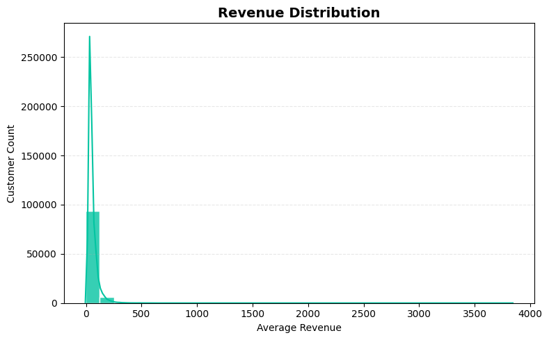

```python
# Revenue Distribution

plt.figure(figsize=(8,5))

sns.histplot(df["rev_Mean"],bins=30,kde=True,color="#03C4A1",edgecolor="white",alpha=0.8)

plt.title("Revenue Distribution",fontsize=14,fontweight="bold")

plt.xlabel("Average Revenue")
plt.ylabel("Customer Count")

plt.grid(axis="y", linestyle="--", alpha=0.3)

plt.tight_layout()

plt.show()
```

*Most customers have revenue between 0 to 200.*

Very few customers go beyond 500. And almost none beyond 1000.

This is a right-skewed distribution — a small number of customers pay very high, but the majority pays low to moderate amounts.

This means a few high-value customers contribute a lot to total revenue. Losing even one of them is costly.

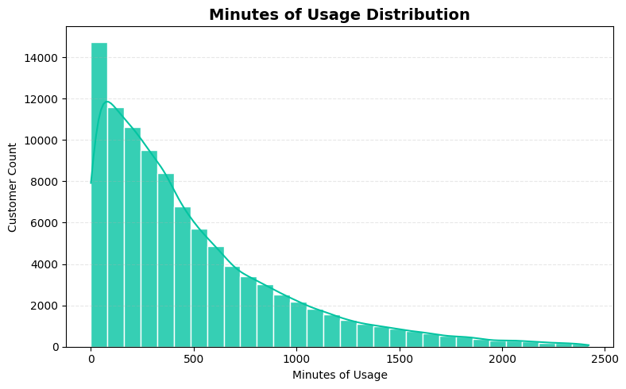

```python
# Monthly Usage Distribution

filtered_mou = df[df["mou_Mean"] < df["mou_Mean"].quantile(0.99)]

plt.figure(figsize=(8,5))

sns.histplot(filtered_mou["mou_Mean"],bins=30,kde=True,color="#03C4A1",
    edgecolor="white",alpha=0.8)

plt.title("Minutes of Usage Distribution",fontsize=14,fontweight="bold")

plt.xlabel("Minutes of Usage")
plt.ylabel("Customer Count")

plt.grid(axis="y", linestyle="--", alpha=0.3)

plt.tight_layout()

plt.show()
```

*Most customers use between 0 to 500 minutes.*

After 500, customer count drops quickly.Very few customers use more than 1500 minutes.

Right-skewed distribution — majority are low to moderate users,very few are heavy users.

Low usage customers are already at higher churn risk as we saw earlier.

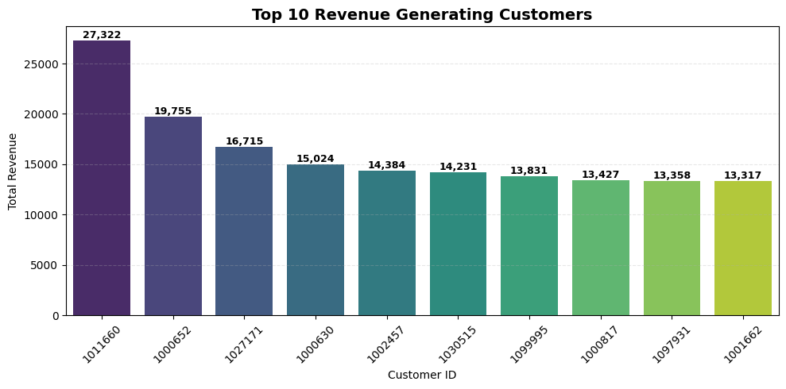

```python
# Top 10 Revenue Customers
top_customers = df.sort_values(by="totrev",ascending=False).head(10)

plt.figure(figsize=(10,5))

ax = sns.barplot(data=top_customers,x="Customer_ID",y="totrev",palette="viridis",order=top_customers["Customer_ID"])

plt.title("Top 10 Revenue Generating Customers",fontsize=14,fontweight="bold")

plt.xlabel("Customer ID")
plt.ylabel("Total Revenue")

plt.xticks(rotation=45)

plt.grid(axis="y", linestyle="--", alpha=0.3)

for p in ax.patches:
    ax.annotate(
        f"{p.get_height():,.0f}",
        (p.get_x() + p.get_width()/2, p.get_height()),
        ha="center",
        va="bottom",
        fontsize=9,
        fontweight="bold"
    )

plt.tight_layout()

plt.show()
```

*Top 10 customers contribute significantly to total revenue.*

Highest: Customer 1011660 — 27,322

Lowest in top 10: Customer 1001662 — 13,317

Even the 10th highest customer generates 13,000+ in revenue.

These are the most valuable customers.If any of them churn, it is a major loss.

Business action: These top customers should get priority for any personal offers, dedicated support, proactive check-ins.

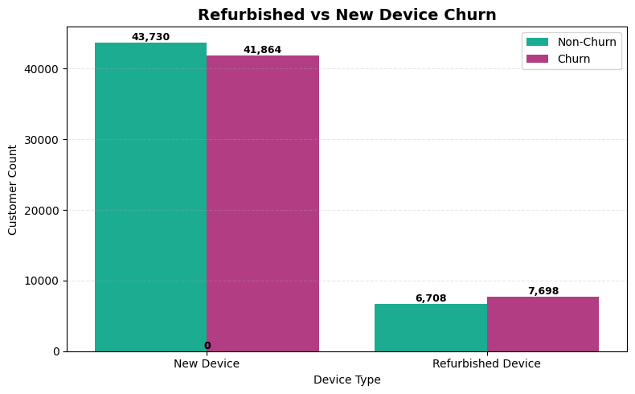

```python
# Device Type Analysis

plt.figure(figsize=(8,5))

ax = sns.countplot(data=df,x="refurb_new",hue="churn",palette=["#03C4A1", "#C52A87"])

plt.title("Refurbished vs New Device Churn",fontsize=14,fontweight="bold")

plt.xlabel("Device Type")
plt.ylabel("Customer Count")

ax.set_xticklabels(["New Device", "Refurbished Device"])

plt.grid(axis="y", linestyle="--", alpha=0.3)


for p in ax.patches:
    ax.annotate(
        f"{int(p.get_height()):,}",
        (p.get_x() + p.get_width()/2, p.get_height()),
        ha="center",
        va="bottom",
        fontsize=9,
        fontweight="bold"
    )


handles, labels = ax.get_legend_handles_labels()
ax.legend(handles, ["Non-Churn", "Churn"])

plt.tight_layout()

plt.show()
```

*Most customers use new devices.*

New Device: Non-Churn: 43,730 Churn: 41,864

Almost equal — no clear pattern.

Refurbished Device: Non-Churn: 6,708 Churn: 7,698

Slightly more churn — but difference is small.

Refurbished device users churn slightly more. Possibly because older/cheaper devices give worse experience.

But overall, device type is a weak signal. Not a strong predictor of churn.

# **Feature Engineering**

```python
# Revenue Segment

df["revenue_segment"] = pd.qcut(
    df["avgrev"],
    q=3,
    labels=["Low Revenue", "Medium Revenue", "High Revenue"]
)
```

```python
df["revenue_segment"].value_counts()
```

```
revenue_segment
Low Revenue       33347
High Revenue      33327
Medium Revenue    33326
Name: count, dtype: int64
```

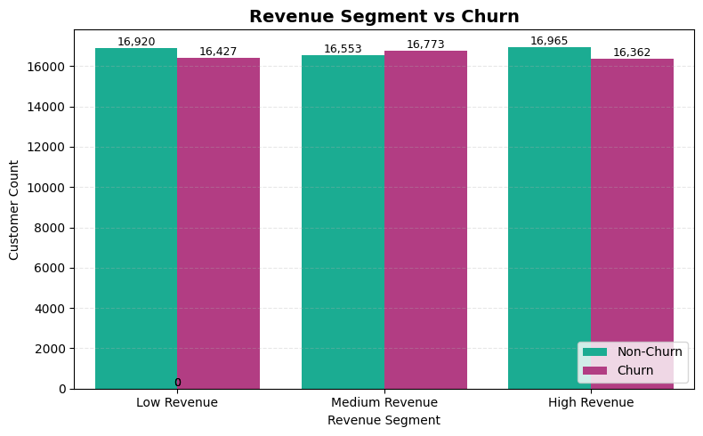

```python
# Revenue Segment vs Churn

plt.figure(figsize=(8,5))

ax = sns.countplot(data=df,x="revenue_segment",hue="churn",palette=["#03C4A1", "#C52A87"])

plt.title("Revenue Segment vs Churn",fontsize=14,fontweight="bold")

plt.xlabel("Revenue Segment")
plt.ylabel("Customer Count")

plt.grid(axis="y", linestyle="--", alpha=0.3)

for p in ax.patches:
    ax.annotate(
        f"{int(p.get_height()):,}",
        (p.get_x() + p.get_width()/2, p.get_height()),
        ha="center",
        va="bottom",
        fontsize=9
    )

handles, labels = ax.get_legend_handles_labels()
ax.legend(handles, ["Non-Churn", "Churn"])

plt.tight_layout()

plt.show()
```

```python
# Usage Segment

df["usage_segment"] = pd.qcut(
    df["avgmou"],
    q=3,
    labels=["Low Usage", "Medium Usage", "High Usage"]
)
```

```python
df["usage_segment"].value_counts()
```

```
usage_segment
Medium Usage    33336
Low Usage       33335
High Usage      33329
Name: count, dtype: int64
```

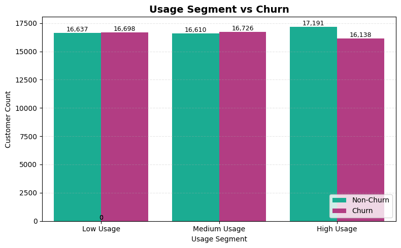

```python
# Usage Segment vs Churn

plt.figure(figsize=(8,5))

ax = sns.countplot(data=df,x="usage_segment",hue="churn",palette=["#03C4A1", "#C52A87"])

plt.title("Usage Segment vs Churn",fontsize=14,fontweight="bold")

plt.xlabel("Usage Segment")
plt.ylabel("Customer Count")

plt.grid(axis="y", linestyle="--", alpha=0.3)

for p in ax.patches:
    ax.annotate(
        f"{int(p.get_height()):,}",
        (p.get_x() + p.get_width()/2, p.get_height()),
        ha="center",
        va="bottom",
        fontsize=9
    )

handles, labels = ax.get_legend_handles_labels()
ax.legend(handles, ["Non-Churn", "Churn"])

plt.tight_layout()

plt.show()
```

```python
# Tenure Group
df["tenure_group"] = pd.cut(
    df["months"],
    bins=[0, 12, 36, 100],
    labels=["New Customer", "Regular Customer", "Loyal Customer"]
)
df["tenure_group"].value_counts()
```

```
tenure_group
Regular Customer    61892
New Customer        32443
Loyal Customer       5665
Name: count, dtype: int64
```

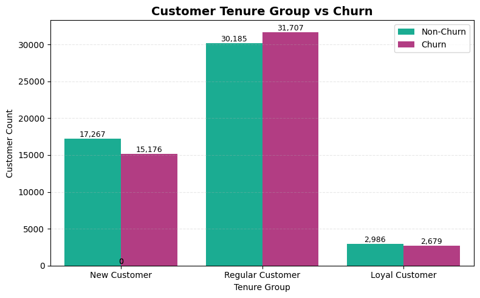

```python
# Tenure Group vs Churn

plt.figure(figsize=(8,5))

ax = sns.countplot(data=df,x="tenure_group",hue="churn",palette=["#03C4A1", "#C52A87"])

plt.title("Customer Tenure Group vs Churn",fontsize=14,fontweight="bold")

plt.xlabel("Tenure Group")
plt.ylabel("Customer Count")

plt.grid(axis="y", linestyle="--", alpha=0.3)

for p in ax.patches:
    ax.annotate(
        f"{int(p.get_height()):,}",
        (p.get_x() + p.get_width()/2, p.get_height()),
        ha="center",
        va="bottom",
        fontsize=9
    )

handles, labels = ax.get_legend_handles_labels()
ax.legend(handles, ["Non-Churn", "Churn"])

plt.tight_layout()

plt.show()
```

```python
# Device Age Group

df["device_age_group"] = pd.cut(
    df["eqpdays"],
    bins=[0, 365, 730, 5000],
    labels=["New Device", "Moderate Device", "Old Device"]
)
df["device_age_group"].value_counts()
```

```
device_age_group
New Device         54518
Moderate Device    34505
Old Device         10811
Name: count, dtype: int64
```

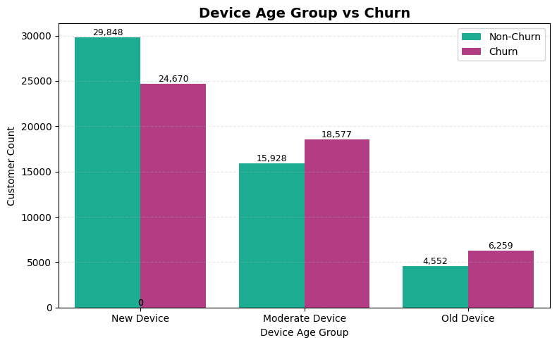

```python
# Device Age Group vs Churn

plt.figure(figsize=(8,5))

ax = sns.countplot(data=df,x="device_age_group",hue="churn",palette=["#03C4A1", "#C52A87"])

plt.title("Device Age Group vs Churn",fontsize=14,fontweight="bold")

plt.xlabel("Device Age Group")
plt.ylabel("Customer Count")

plt.grid(axis="y", linestyle="--", alpha=0.3)

for p in ax.patches:
    ax.annotate(
        f"{int(p.get_height()):,}",
        (p.get_x() + p.get_width()/2, p.get_height()),
        ha="center",
        va="bottom",
        fontsize=9
    )

handles, labels = ax.get_legend_handles_labels()
ax.legend(handles, ["Non-Churn", "Churn"])

plt.tight_layout()

plt.show()
```

```python
# Service Issue Score

df["service_issue_score"] = df["drop_vce_Mean"] + df["blck_vce_Mean"] + df["custcare_Mean"] + df["callwait_Mean"]
```

```python
# Customer Value Score

df["customer_value_score"] = df["totrev"] + df["adjrev"] + df["avgrev"]
```

```python
# Customer Engagement Score

df["customer_engagement_score"] = (df["mou_Mean"] +df["totcalls"] +df["complete_Mean"])
```

```python
df[["revenue_segment", "usage_segment", "tenure_group", "device_age_group", "service_issue_score", "customer_value_score","customer_engagement_score"]].head()
```

|  | revenue_segment | usage_segment | tenure_group | device_age_group | service_issue_score | customer_value_score | customer_engagement_score |
| --- | --- | --- | --- | --- | --- | --- | --- |
| 0 | Low Revenue | Low Usage | Loyal Customer | New Device | 1.666667 | 2987.72 | 1916.250000 |
| 1 | Medium Revenue | Medium Usage | Loyal Customer | New Device | 16.666667 | 5737.09 | 15330.083333 |
| 2 | Low Revenue | Medium Usage | Loyal Customer | Old Device | 0.333333 | 4124.92 | 7919.250000 |
| 3 | Medium Revenue | Low Usage | Loyal Customer | Old Device | 0.000000 | 3983.16 | 1513.166667 |
| 4 | Low Revenue | Medium Usage | Loyal Customer | Moderate Device | 19.000000 | 4386.29 | 5192.500000 |

```python
# Revenue Per Month

df["revenue_per_month"] = (
    df["totrev"] / (df["months"] + 1)
)
```

```python
df.sort_values(
    by="revenue_per_month",
    ascending=False
)[["Customer_ID", "totrev", "months", "revenue_per_month"]].head(10)
```

|  | Customer_ID | totrev | months | revenue_per_month |
| --- | --- | --- | --- | --- |
| 11659 | 1011660 | 27321.50 | 31 | 853.796875 |
| 27170 | 1027171 | 16715.21 | 19 | 835.760500 |
| 62476 | 1062477 | 9738.89 | 14 | 649.259333 |
| 30514 | 1030515 | 14231.32 | 21 | 646.878182 |
| 49335 | 1049336 | 9632.29 | 15 | 602.018125 |
| 84878 | 1084879 | 7186.94 | 12 | 552.841538 |
| 99994 | 1099995 | 13830.66 | 25 | 531.948462 |
| 91008 | 1091009 | 6095.52 | 11 | 507.960000 |
| 49098 | 1049099 | 7108.33 | 13 | 507.737857 |
| 56355 | 1056356 | 5923.12 | 11 | 493.593333 |

```python
# Call Completion Rate

df["call_completion_rate"] = (df["complete_Mean"] / (df["attempt_Mean"] + 1))
```

```python
df[["Customer_ID","attempt_Mean","complete_Mean","call_completion_rate"]].head()
```

|  | Customer_ID | attempt_Mean | complete_Mean | call_completion_rate |
| --- | --- | --- | --- | --- |
| 0 | 1000001 | 52.333333 | 45.000000 | 0.843750 |
| 1 | 1000002 | 263.333333 | 193.333333 | 0.731400 |
| 2 | 1000003 | 9.000000 | 6.000000 | 0.600000 |
| 3 | 1000004 | 3.666667 | 3.666667 | 0.785714 |
| 4 | 1000005 | 222.333333 | 137.000000 | 0.613433 |

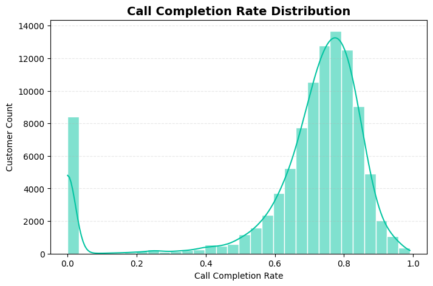

```python
plt.figure(figsize=(8,5))

sns.histplot(
    df["call_completion_rate"],
    bins=30,
    kde=True,
    color="#03C4A1",
    edgecolor="white"
)

plt.title("Call Completion Rate Distribution",
          fontsize=14,
          fontweight="bold")

plt.xlabel("Call Completion Rate")
plt.ylabel("Customer Count")

plt.grid(axis="y", linestyle="--", alpha=0.3)

plt.show()
```

*Two separate groups are visible in this chart.*

Group 1: around 0.0 . A small group of customers with almost zero call completion rate.These customers can barely make calls.

Group 2: around 0.75 to 0.80 . The majority of customers fall here.Most calls are successfully completed.

This bimodal pattern is interesting —it suggests two very different customer experiences exist.

Customers in group 1 (near 0.0) are likely very frustrated. Poor call completion = poor service experience = higher churn risk.

```python
# Service Failure Rate

df["service_failure_rate"] = (df["drop_blk_Mean"] / (df["attempt_Mean"] + 1))
```

```python
df.sort_values(
    by="service_failure_rate",
    ascending=False
)[["Customer_ID","drop_blk_Mean","attempt_Mean","service_failure_rate"]].head(10)
```

|  | Customer_ID | drop_blk_Mean | attempt_Mean | service_failure_rate |
| --- | --- | --- | --- | --- |
| 8737 | 1008738 | 4.000000 | 0.000000 | 4.000000 |
| 44682 | 1044683 | 20.666667 | 21.333333 | 0.925373 |
| 24431 | 1024432 | 98.666667 | 106.000000 | 0.922118 |
| 60440 | 1060441 | 29.000000 | 30.666667 | 0.915789 |
| 81956 | 1081957 | 10.666667 | 10.666667 | 0.914286 |
| 78408 | 1078409 | 7.333333 | 7.333333 | 0.880000 |
| 40317 | 1040318 | 9.000000 | 9.333333 | 0.870968 |
| 20872 | 1020873 | 4.333333 | 4.000000 | 0.866667 |
| 58721 | 1058722 | 6.333333 | 6.333333 | 0.863636 |
| 18882 | 1018883 | 288.000000 | 337.333333 | 0.851232 |

```python
#High Risk Customer Flag

df["high_risk_customer"] = np.where(((df["service_issue_score"] > df["service_issue_score"].median()) &(df["months"] < 12)
    ),
    1,
    0
)
```

```python
df["service_issue_median_score"] = (df["service_issue_score"].median())
service_issue_median_score
```

[output not shown]

```python
df.sort_values(
    by="high_risk_customer",
    ascending=False
)[["Customer_ID","service_issue_score","service_issue_median_score","months","high_risk_customer"]].head(10)
```

|  | Customer_ID | service_issue_score | service_issue_median_score | months | high_risk_customer |
| --- | --- | --- | --- | --- | --- |
| 41042 | 1041043 | 18.666667 | 7.0 | 9 | 1 |
| 41184 | 1041185 | 25.000000 | 7.0 | 11 | 1 |
| 42361 | 1042362 | 8.333333 | 7.0 | 7 | 1 |
| 16380 | 1016381 | 10.000000 | 7.0 | 8 | 1 |
| 87499 | 1087500 | 15.333333 | 7.0 | 6 | 1 |
| 21989 | 1021990 | 8.666667 | 7.0 | 11 | 1 |
| 48951 | 1048952 | 34.000000 | 7.0 | 7 | 1 |
| 40681 | 1040682 | 21.666667 | 7.0 | 11 | 1 |
| 27886 | 1027887 | 10.666667 | 7.0 | 6 | 1 |
| 21848 | 1021849 | 33.000000 | 7.0 | 7 | 1 |

# **Data Preprocessing**

```python
# Drop Customer_ID Before Model
df_model = df.copy()
df_model = df_model.drop(columns=["Customer_ID"])
```

```python
df_model["churn"].value_counts()
```

```
churn
0    50438
1    49562
Name: count, dtype: int64
```

```python
# Separate Features and Target

X = df_model.drop(columns=["churn"])
y = df_model["churn"]
```

```python
print(X.shape)
print(y.shape)
```

```
(100000, 77)
(100000,)
```

```python
# One Hot Encoding

X = pd.get_dummies(X, drop_first=True)
```

```python
X.shape
```

```
(100000, 101)
```

```python
# Train Test Split

X_train, X_test, y_train, y_test = train_test_split(
    X, y, test_size=0.2, random_state=42, stratify=y
)
```

```python
print(X_train.shape)
print(X_test.shape)

print(y_train.shape)
print(y_test.shape)
```

```
(80000, 101)
(20000, 101)
(80000,)
(20000,)
```

```python
print(y_train.value_counts(normalize=True))

print(y_test.value_counts(normalize=True))
```

```
churn
0    0.504375
1    0.495625
Name: proportion, dtype: float64
churn
0    0.5044
1    0.4956
Name: proportion, dtype: float64
```

```python
# Scaling

scaler = StandardScaler()

X_train_scaled = scaler.fit_transform(X_train)
X_test_scaled = scaler.transform(X_test)
```

```python
print(X_train_scaled.shape)
print(X_test_scaled.shape)
```

```
(80000, 101)
(20000, 101)
```

```python
X_train_scaled[:5]
```

[output not shown]

[output cut: 50 more lines]

```
         0.16944299, -0.42765911, -0.45107898,  0.1666433 ,  1.07487656,
         2.29476666,  2.26028268,  0.89889604,  1.27415769,  2.01225169,
         0.95684503,  0.46393481, -0.60005452, -0.60774287, -0.47957626,
        -0.29857437, -0.31640167,  0.08622066, -0.54351479, -0.65639028,
         2.81009498, -0.41027891,  0.1634535 ,  0.97526324, -0.07275939,
        -0.3876123 ,  2.39469698,  0.        ,  0.70290142, -0.48807539,
         2.48015274, -0.21229362, -0.04801356, -1.61502854, -0.41123237,
        -0.4010615 ,  0.40514732, -0.14376557,  0.48960622, -0.27645301,
        -0.66906605, -0.46373308,  1.24837673, -0.2350952 , -0.1241323 ,
        -0.08714784, -0.07342623, -0.06416291, -0.06104371, -0.0548546 ,
        -0.05298926, -0.11991172, -0.08282046, -0.06981144, -0.06206676,
        -0.10050378, -0.10696699, -0.20429021, -0.22142491, -0.2969823 ,
        -0.31128307, -0.3335879 , -1.49051987, -0.70780959,  1.41567322,
        -0.70677535,  1.4119362 , -1.27233226, -0.24462479, -0.72348621,
        -0.34935814]])
```

# **Machine Learning Model**

```python
# Logistic Regression

model = LogisticRegression(max_iter = 1000)
model.fit(X_train_scaled,y_train)
```

```
LogisticRegression(max_iter=1000)
```

```python
# Prediction

y_pred = model.predict(X_test_scaled)
```

```python
# Prediction Probability

y_pred_proba = model.predict_proba(X_test_scaled)[:, 1]
```

```python
y_pred[:10]
```

```
array([1, 0, 0, 0, 0, 1, 1, 1, 1, 0])
```

```python
y_pred_proba[:10]
```

```
array([0.63188856, 0.49283047, 0.28877961, 0.44631066, 0.25639988,
       0.63517359, 0.66142359, 0.51493327, 0.72104969, 0.35362168])
```

# **Model Evaluation**

```python
accuracy = accuracy_score(y_test, y_pred)
precision = precision_score(y_test, y_pred)
recall = recall_score(y_test, y_pred)
f1 = f1_score(y_test, y_pred)

print(f"Accuracy: {accuracy:.2%}")
print(f"Precision: {precision:.2%}")
print(f"Recall: {recall:.2%}")
print(f"F1 Score: {f1:.2%}")
```

```
Accuracy: 59.09%
Precision: 58.77%
Recall: 58.50%
F1 Score: 58.64%
```

```python
# Classification Report

print(classification_report(y_test, y_pred))
```

```
              precision    recall  f1-score   support

           0       0.59      0.60      0.60     10088
           1       0.59      0.59      0.59      9912

    accuracy                           0.59     20000
   macro avg       0.59      0.59      0.59     20000
weighted avg       0.59      0.59      0.59     20000
```

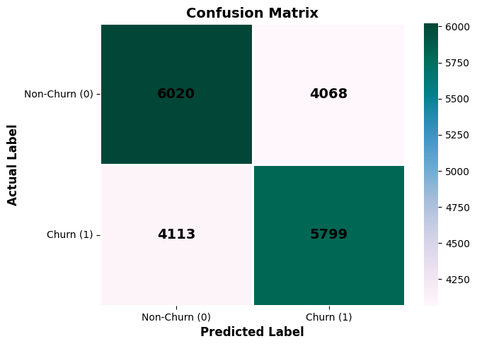

```python
# Confusion Matrix

cm = confusion_matrix(y_test, y_pred)

plt.figure(figsize=(7,5))

sns.heatmap(cm,annot=True,fmt="d",cmap="PuBuGn",linewidths=1,linecolor="white",cbar=True,
    annot_kws={"fontsize":14,"fontweight":"bold", "color":"black"}
)

plt.title("Confusion Matrix",fontsize=14,fontweight="bold")

plt.xlabel("Predicted Label",fontsize=12,fontweight="bold")

plt.ylabel("Actual Label",fontsize=12,fontweight="bold")

plt.xticks([0.5,1.5], ["Non-Churn (0)", "Churn (1)"])
plt.yticks([0.5,1.5], ["Non-Churn (0)", "Churn (1)"], rotation=0)

plt.tight_layout()

plt.show()
```

*Confusion Matrix breakdown:*

True Negative (6020): Predicted No Churn, Actually No Churn. CORRECT.

False Positive (4068): Predicted Churn, Actually No Churn. WRONG.

False Negative (4113): Predicted No Churn, Actually Churned. WRONG.

True Positive (5799): Predicted Churn, Actually Churned. CORRECT.

Total correct: 6020 + 5799 = 11,819

Total wrong: 4068 + 4113 = 8,181

Model is doing okay but making too many errors.

Most dangerous error: False Negative (4113) . These are real churners the model MISSED.

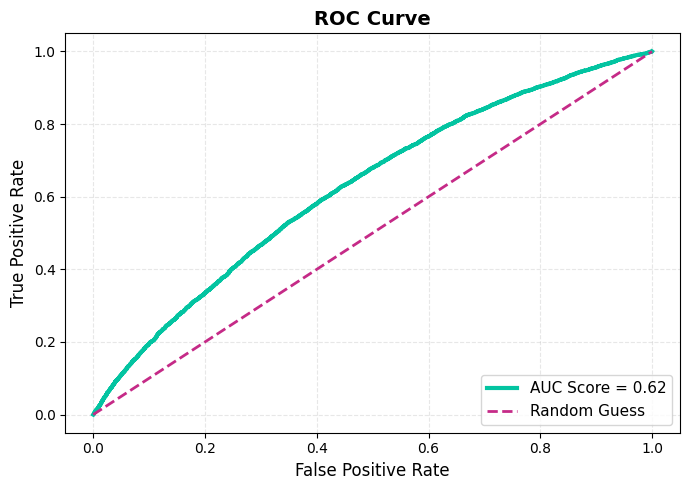

```python
# Receiver Operating Characteristic (ROC Curve) and Area Under the Curve (AUC)

fpr, tpr, thresholds = roc_curve(y_test,y_pred_proba)

auc_score = roc_auc_score(y_test,y_pred_proba)

plt.figure(figsize=(7,5))

plt.plot(fpr,tpr,color="#03C4A1",linewidth=3,label=f"AUC Score = {auc_score:.2f}")

plt.plot([0,1],[0,1],linestyle="--",color="#C52A87",linewidth=2,label="Random Guess")

plt.title("ROC Curve",fontsize=14,fontweight="bold")

plt.xlabel("False Positive Rate",fontsize=12)

plt.ylabel("True Positive Rate",fontsize=12)

plt.legend(fontsize=11,loc="lower right")

plt.grid(linestyle="--",alpha=0.3)

plt.tight_layout()

plt.show()
```

```python
feature_importance = pd.DataFrame({"Feature": X.columns,"Coefficient": model.coef_[0]})

feature_importance["Abs_Coefficient"] = feature_importance["Coefficient"].abs()

feature_importance.sort_values(by="Abs_Coefficient", ascending=False).head(20)
```

|  | Feature | Coefficient | Abs_Coefficient |
| --- | --- | --- | --- |
| 13 | ccrndmou_Mean | -0.548768 | 0.548768 |
| 14 | cc_mou_Mean | 0.445530 | 0.445530 |
| 1 | mou_Mean | -0.420128 | 0.420128 |
| 49 | eqpdays | 0.369918 | 0.369918 |
| 35 | avgmou | 0.347100 | 0.347100 |
| 32 | adjrev | -0.267206 | 0.267206 |
| 31 | totrev | 0.217166 | 0.217166 |
| 36 | avg3mou | -0.208589 | 0.208589 |
| 22 | drop_blk_Mean | -0.208398 | 0.208398 |
| 24 | complete_Mean | 0.199614 | 0.199614 |
| 18 | peak_vce_Mean | -0.183785 | 0.183785 |
| 33 | adjmou | -0.161757 | 0.161757 |
| 27 | uniqsubs | 0.158055 | 0.158055 |
| 20 | opk_vce_Mean | -0.154976 | 0.154976 |
| 54 | call_completion_rate | -0.145863 | 0.145863 |
| 30 | totmou | 0.142623 | 0.142623 |
| 6 | drop_vce_Mean | 0.128327 | 0.128327 |
| 3 | ovrrev_Mean | 0.122684 | 0.122684 |
| 4 | change_mou | -0.120370 | 0.120370 |
| 50 | service_issue_score | 0.118301 | 0.118301 |

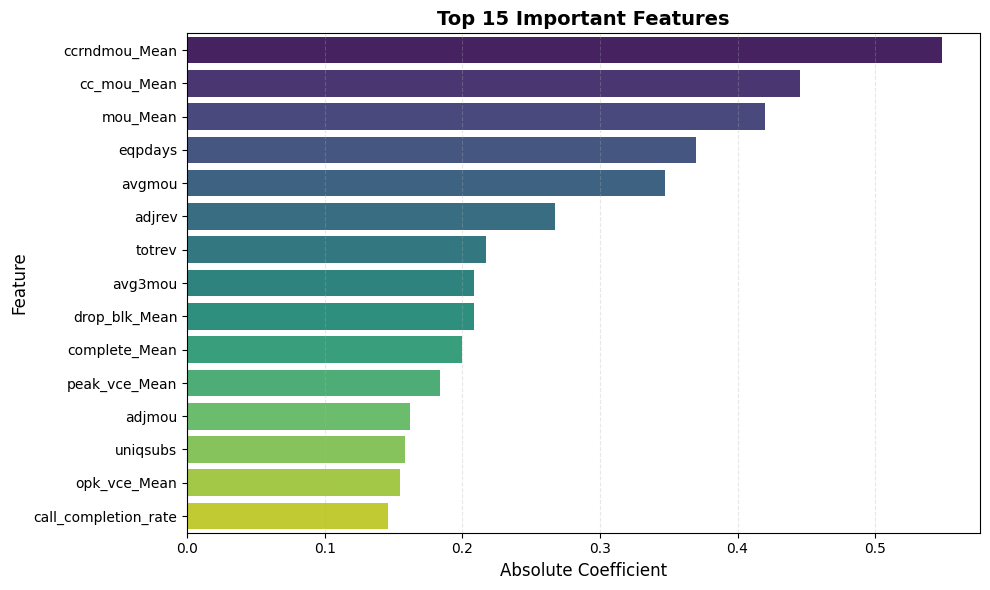

```python
top_features = feature_importance.sort_values(by="Abs_Coefficient",ascending=False).head(15)

plt.figure(figsize=(10,6))

sns.barplot(data=top_features,x="Abs_Coefficient",y="Feature",palette="viridis")

plt.title("Top 15 Important Features",fontsize=14,fontweight="bold")

plt.xlabel("Absolute Coefficient",fontsize=12)

plt.ylabel("Feature",fontsize=12)

plt.grid(
    axis="x",
    linestyle="--",
    alpha=0.3
)

plt.tight_layout()

plt.show()
```

```python
# Final Prediction System

sample_customer = X_test.iloc[0:1]

sample_scaled = scaler.transform(sample_customer)

prediction = model.predict(sample_scaled)
probability = model.predict_proba(sample_scaled)[:, 1]

print("Prediction:", prediction[0])
if prediction[0] == 1:
    print(f"This customer is likely to churn. Churn Probability: {probability[0]:.2%}")
else:
    print(f"This customer is not likely to churn. Churn Probability: {probability[0]:.2%}")
```

```
Prediction: 1
This customer is likely to churn. Churn Probability: 63.19%
```

# **Final Business Insights**

    The model performs better than random guessing, but still misses many real churn customers.

# **Save Clean Dataset**

```python
df.to_csv("final_cleaned_telecom_customer_churn.csv", index=False)
```